# ACTG175 Continuous Analysis: Applied Operating-Characteristic Evaluation

```r
library(gt)

# ---------------------------------------------------------------------------
# Output location for this document's results:  <base>/<dirout>/
#   results_dir = NULL -> base is <qmd dir>/_payloads
#   dirout      = NULL -> the .qmd stem
# ---------------------------------------------------------------------------
results_dir <- NULL
dirout      <- NULL

# This document reads the stored evaluation objects only; it computes nothing
# heavy and types no number.  The draw sets behind it were produced by
# dev/glm-continuous-sims/oc_applied_eval_rung_2026-08-31.R (eleven rungs,
# 2e5 draws each) and assembled by oc_applied_eval_summary_2026-08-31.R.
.qmd_dir <- tryCatch(dirname(knitr::current_input(dir = TRUE)),
                     error = function(e) getwd())
repo_root <- normalizePath(file.path(.qmd_dir, "..", "..", ".."))
S <- readRDS(file.path(repo_root, "dev", "glm-continuous-sims",
                       "oc_applied_eval_summary_2026-08-31.rds"))

fmt  <- function(x, d = 3) formatC(x, format = "f", digits = d)
fmt0 <- function(x) formatC(x, format = "d")
pct  <- function(x, d = 1) paste0(fmt(100 * x, d), "%")
```

## 0.1 1. The analysis and its anchor

The applied analysis this evaluation attaches to is the ACTG175 continuous harm search of `analysis_actg175_continuous_compare_all.qmd`: outcome `y_decline` (CD4 decline, adverse scale) on the ZDV+ddI vs ddI arms (N = 1083), twelve confounders (six continuous with `jcuts = 10`, six binary), thresholds c1 = 10 and c2 = 5 on the mean-difference scale, `consistency_method = "resample"` with `pconsistency = 0.90`, `n.min = 60`, `maxk = 2`.

The evaluation attaches to the **fixed-family `maxeffCons` configuration** — the MR-anchor configuration of that document, with `use_lasso = use_grf = use_dina = FALSE`. That is the document’s own rationale for its anchor: multiplier-resampling inference and the lasso/GRF front ends are mutually exclusive under `subgroup_method = "consistency"` (the family would be estimated from the same data the search runs on), so the inferential anchor runs with the front ends off, and the operating characteristics evaluated here are the operating characteristics of exactly that procedure. With the front ends off the candidate family is enumerated from the covariates and their quantile cuts alone; the cut locations are still quantile-derived (“no-front-end” rather than literally fixed), and the evaluation holds this family fixed — see the limitations.

The anchor that analysis found: **Ĥ = `{age <= 37} & !{cd40 <= 507}`**, n(Ĥ) = 66 of 1083, fitted mean difference **T̂<sub>obs</sub> = 87.916667** CD4 units, consistency 0.95. The ITT mean difference on `y_decline` is -27.59 (SE 7.89) — on average the combination arm *reduces* CD4 decline, so a harm subgroup, if real, sits against a beneficial background.

## 0.2 2. The anchored DGM

Truths are anchored to the analysis data by a two-point mixture stylization, stated plainly: the super-population (n = 5000 draws of the covariate rows) has exactly two treatment-effect values — the fitted background effect -26.978725 on Q<sup>c</sup> and a planted effect q on Q — with the baseline outcome surface and residual scale (σ = 122.81) taken from the baseline GLM fit to the analysis data. Nothing else about the joint covariate law is modeled; the covariate rows are the data’s own.

Q is the found rule carried into the generator by its clause mapping (`age = 37`; `cd40 = list(type = "greater", value = 507)`), reproducing Ĥ’s membership subject-for-subject on the analysis frame (66/66). On the super-population Q has prevalence 0.0634.

**Q’s representability in the discovery family.** The evaluation family is the analyst’s own discovery grid at n = 1083 (M = 4508 candidate rules after floors and deduplication), kept pure: Q is *not* forced in. Ĥ’s `cd40` threshold (507) lies just off the population quantile grid (nearest grid cut 506), so no member is identical to Ĥ; the nearest member (`age <= 37 & cd40 > 506`) matches it with purity and Jaccard 0.9969 — the grid expresses the found rule to within about 0.31% of its membership. This is reported as a feature of the evaluation: the search is scored on the family it actually searches.

**The rungs.** One effect ladder, q ∈ {0.01, 2.50, 5, 7.50, 10, 15, 20, 30, 40, 60, 87.92} CD4 units: from essentially zero (q = 0.01, the zero-plus structural null) through the observed statistic (q = T̂<sub>obs</sub> = 87.92). Each rung is one 2e+05-draw set (seed 8316951) with every threshold c1 ∈ {0, 1, …, 200, T̂<sub>obs</sub>} swept against it at the analyst’s c2 = 5. Across rungs the family’s memberships, prevalences, standard errors and overlap matrix are bit-identical (gated); only the planted effect moves, and each candidate’s oriented mean moves linearly in q through its purity.

## 0.3 3. Type-I under the structural null

**Why the zero-plus rung, not the null branch.** Version 0.3.2 orients every candidate’s mean by the harm direction s = sign(m<sub>τ</sub>[Q]), so the oriented means are the signed mixture s·(m<sub>τ</sub>[Q<sup>c</sup>] + (m<sub>τ</sub>[Q] − m<sub>τ</sub>[Q<sup>c</sup>])·PQg): benefit-direction rules carry oriented-*negative* means, and a planted effect of exactly zero is rejected (no harm direction to orient by) — deliberately. The wrapper’s null *branch*, by contrast, keeps its pre-0.3.2 oriented-absolute reading of the single common effect: on this population it would turn the fitted −27 benefit into a +27 “harm”, and stage 0 measured exactly that — false declaration 1.000 under the null branch at the analyst’s gate. That reading is nonsense here (it is correct for the MD40-style fixtures whose generators hand the search a positive-adverse outcome), so the null branch is not edited and not used. The operational structural null is the alternative branch at q = 0.01 — correctly signed under 0.3.2, and the same truth as “no subgroup” to a hundredth of a CD4 unit.

At the analyst’s gate (c1 = 10, c2 = 5), the search’s family-wise false-declaration rate under this structural null is **0.58500** (MC SE 0.00110).

Read at 1-unit resolution — the resolution of this document’s integer c1 grid — the smallest integer c1 holding type-I at or below 0.05 is **c1<sub>05</sub> = 86** (rate 0.04961 ± 0.00049), and at or below 0.10 is **c1<sub>10</sub> = 79** (rate 0.09818 ± 0.00067).

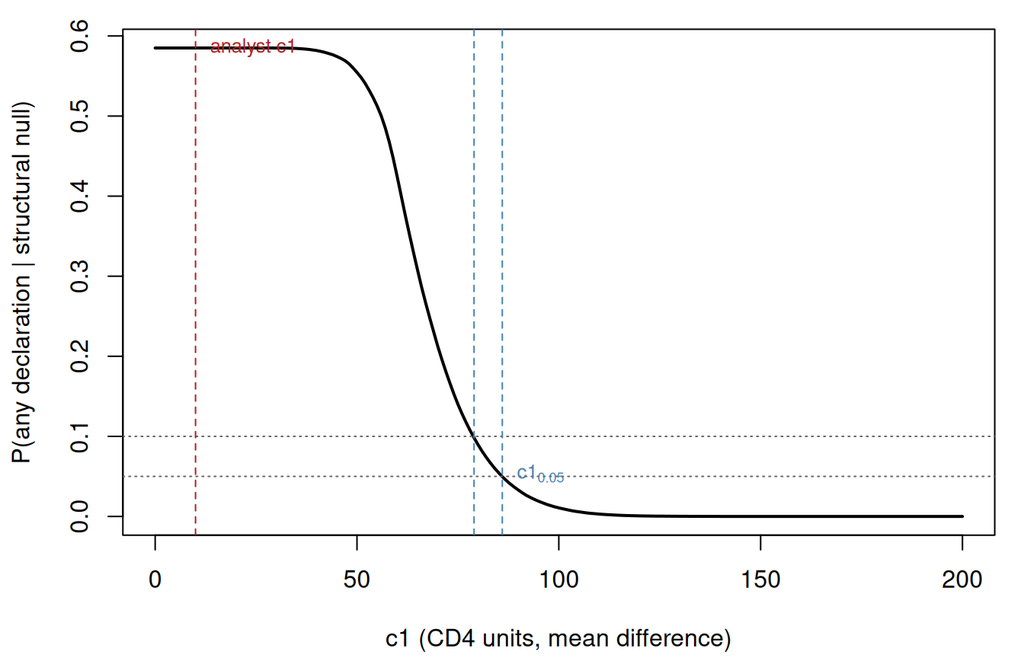

Type-I error of the search under the zero-plus structural null, against the screening threshold c1 (c2 fixed at the analyst’s value). Guides: the analyst’s c1, and c1_05 / c1_10 at the 0.05 / 0.10 lines.

```r
tc <- S$type1$curve
op <- par(mar = c(4.2, 4.2, 1, 1))
plot(tc$c1, tc$det_rate, type = "l", lwd = 2,
     xlab = "c1 (CD4 units, mean difference)",
     ylab = "P(any declaration | structural null)")
abline(h = c(0.05, 0.10), lty = 3, col = "grey40")
abline(v = S$meta$analyst_c1, lty = 2, col = "firebrick")
abline(v = c(S$meta$c1_05, S$meta$c1_10), lty = 2, col = "steelblue")
text(S$meta$analyst_c1, max(tc$det_rate), "analyst c1", pos = 4, cex = 0.8,
     col = "firebrick")
text(S$meta$c1_05, 0.05, expression(c1[0.05]), pos = 4, cex = 0.8,
     col = "steelblue")
```

```r
par(op)
```

## 0.4 4. The effect ladder: power at fixed type-I

Per rung, the declaration rate at the analyst’s c1 and the power at the fixed-type-I thresholds c1<sub>05</sub> and c1<sub>10</sub>; the last three columns give the largest integer c1 at which the rung still holds 80 / 90 / 95% power (read from the grid at 1-unit resolution; no separate inversion calls).

```r
ld <- S$ladder
gt(data.frame(
  q = sapply(ld$q, function(x) fmt(x, ifelse(x %% 1 == 0, 1, 2))),
  det10 = paste0(fmt(ld$det_at_analyst, 4), " ± ",
                 fmt(ld$det_at_analyst_se, 4)),
  p05 = paste0(fmt(ld$power_at_c1_05, 4), " ± ",
               fmt(ld$power_at_c1_05_se, 4)),
  p10 = paste0(fmt(ld$power_at_c1_10, 4), " ± ",
               fmt(ld$power_at_c1_10_se, 4)),
  c80 = ifelse(is.na(ld$c1_pow80), "—", fmt0(ld$c1_pow80)),
  c90 = ifelse(is.na(ld$c1_pow90), "—", fmt0(ld$c1_pow90)),
  c95 = ifelse(is.na(ld$c1_pow95), "—", fmt0(ld$c1_pow95)))) |>
  cols_label(q = "q (planted MD)",
             det10 = md(paste0("rate at c1 = ",
                               fmt0(S$meta$analyst_c1))),
             p05 = md(paste0("power at c1&#8320;&#8325; = ",
                             fmt0(S$meta$c1_05))),
             p10 = md(paste0("power at c1&#8321;&#8320; = ",
                             fmt0(S$meta$c1_10))),
             c80 = "c1 at 80%", c90 = "c1 at 90%", c95 = "c1 at 95%") |>
  tab_source_note(md(paste0(
    "One ", format(S$meta$draws, big.mark = ","),
    "-draw set per rung; ± is the Monte-Carlo SE. ",
    "— = the target rate is not attained at any integer c1 ≥ 0.")))
```

| q (planted MD) | rate at c1 = 10 | power at c1₀₅ = 86 | power at c1₁₀ = 79 | c1 at 80% | c1 at 90% | c1 at 95% |
| --- | --- | --- | --- | --- | --- | --- |
| 0.01 | 0.5850 ± 0.0011 | 0.0496 ± 0.0005 | 0.0982 ± 0.0007 | — | — | — |
| 2.50 | 0.5945 ± 0.0011 | 0.0527 ± 0.0005 | 0.1030 ± 0.0007 | — | — | — |
| 5.0 | 0.6048 ± 0.0011 | 0.0566 ± 0.0005 | 0.1083 ± 0.0007 | — | — | — |
| 7.50 | 0.6156 ± 0.0011 | 0.0604 ± 0.0005 | 0.1147 ± 0.0007 | — | — | — |
| 10.0 | 0.6267 ± 0.0011 | 0.0650 ± 0.0006 | 0.1213 ± 0.0007 | — | — | — |
| 15.0 | 0.6497 ± 0.0011 | 0.0756 ± 0.0006 | 0.1377 ± 0.0008 | — | — | — |
| 20.0 | 0.6733 ± 0.0010 | 0.0891 ± 0.0006 | 0.1572 ± 0.0008 | — | — | — |
| 30.0 | 0.7248 ± 0.0010 | 0.1268 ± 0.0007 | 0.2087 ± 0.0009 | — | — | — |
| 40.0 | 0.7789 ± 0.0009 | 0.1819 ± 0.0009 | 0.2779 ± 0.0010 | — | — | — |
| 60.0 | 0.8784 ± 0.0007 | 0.3500 ± 0.0011 | 0.4639 ± 0.0011 | 59 | — | — |
| 87.92 | 0.9660 ± 0.0004 | 0.6604 ± 0.0011 | 0.7534 ± 0.0010 | 75 | 65 | 57 |

One 2e+05-draw set per rung; ± is the Monte-Carlo SE. — = the target rate is not attained at any integer c1 ≥ 0.

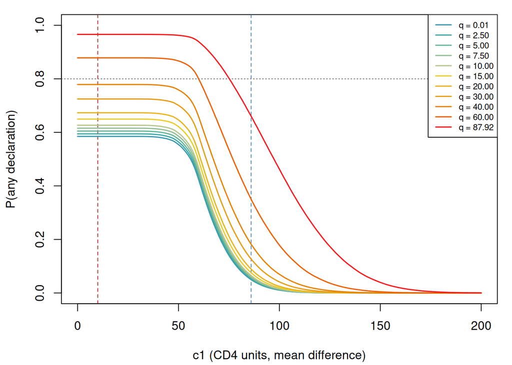

Declaration curves: the probability of any declaration against c1, one curve per rung (the zero-plus structural null lowest). Guides: c1_05, the analyst’s c1, and the 0.80 power line.

```r
cv <- S$curves
qs <- unique(cv$q)
cols <- hcl.colors(length(qs), "Zissou 1")
op <- par(mar = c(4.2, 4.2, 1, 1))
plot(NA, xlim = range(cv$c1), ylim = c(0, 1),
     xlab = "c1 (CD4 units, mean difference)", ylab = "P(any declaration)")
abline(h = 0.80, lty = 3, col = "grey40")
abline(v = c(S$meta$c1_05, S$meta$analyst_c1), lty = 2,
       col = c("steelblue", "firebrick"))
for (k in seq_along(qs)) {
  d <- cv[cv$q == qs[k], ]
  lines(d$c1, d$det_rate, lwd = 1.6, col = cols[k])
}
legend("topright", legend = sapply(qs, function(x) paste0("q = ", fmt(x, 2))),
       col = cols, lwd = 1.6, cex = 0.7, bg = "white")
```

```r
par(op)
```

## 0.5 5. What is declared, per rung

Conditional on declaring at the analyst’s gate: the expected size of the declared subgroup, its expected overlap quality against Q (PPV, sensitivity, specificity), the expected true oriented effect on the declared rule, the naive selection bias, and the selection mass on rules whose true mean is below c1.

```r
dc <- S$declared
gt(data.frame(
  q = sapply(dc$q, function(x) fmt(x, ifelse(x %% 1 == 0, 1, 2))),
  EnH = paste0(fmt(dc$EnH, 1), " ± ", fmt(dc$EnH_se, 2)),
  Eppv = paste0(fmt(dc$Eppv, 3), " ± ", fmt(dc$Eppv_se, 4)),
  Esens = paste0(fmt(dc$Esens, 3), " ± ", fmt(dc$Esens_se, 4)),
  Espec = paste0(fmt(dc$Espec, 3), " ± ", fmt(dc$Espec_se, 4)),
  EbetaH = paste0(fmt(dc$EbetaH, 2), " ± ", fmt(dc$EbetaH_se, 3)),
  naive = paste0(fmt(dc$Enaive_bias, 2), " ± ~",
                 fmt(dc$Enaive_bias_se_approx, 3)),
  mb = paste0(fmt(dc$mass_below, 3), " ± ", fmt(dc$mass_below_se, 4)))) |>
  cols_label(q = "q", EnH = md("E\\|Ĥ\\|"), Eppv = "E[PPV]",
             Esens = "E[sens]", Espec = "E[spec]",
             EbetaH = md("E[β(Ĥ)]"), naive = "E[naive − β(Ĥ)]",
             mb = "mass below c1") |>
  tab_source_note(md(paste0(
    "All conditional on declaration at (c1 = ", fmt0(S$meta$analyst_c1),
    ", c2 = ", fmt0(S$meta$analyst_c2), "). ± is the delta-method MC SE ",
    "from the multinomial selection counts; the naive-bias SE (marked ~) ",
    "treats the winner's noise scale as se_g and is approximate.")))
```

| q | E\|Ĥ\| | E[PPV] | E[sens] | E[spec] | E[β(Ĥ)] | E[naive − β(Ĥ)] | mass below c1 |
| --- | --- | --- | --- | --- | --- | --- | --- |
| 0.01 | 75.8 ± 0.06 | 0.174 ± 0.0008 | 0.180 ± 0.0008 | 0.937 ± 0.0001 | -22.29 ± 0.021 | 89.93 ± ~0.089 | 1.000 ± 0.0000 |
| 2.50 | 75.6 ± 0.05 | 0.186 ± 0.0008 | 0.192 ± 0.0008 | 0.938 ± 0.0001 | -21.49 ± 0.024 | 89.38 ± ~0.088 | 1.000 ± 0.0000 |
| 5.0 | 75.4 ± 0.05 | 0.200 ± 0.0008 | 0.206 ± 0.0008 | 0.940 ± 0.0001 | -20.59 ± 0.026 | 88.74 ± ~0.087 | 1.000 ± 0.0000 |
| 7.50 | 75.2 ± 0.05 | 0.214 ± 0.0009 | 0.220 ± 0.0008 | 0.941 ± 0.0001 | -19.59 ± 0.029 | 88.04 ± ~0.087 | 1.000 ± 0.0000 |
| 10.0 | 75.0 ± 0.05 | 0.229 ± 0.0009 | 0.234 ± 0.0009 | 0.942 ± 0.0001 | -18.51 ± 0.032 | 87.27 ± ~0.086 | 1.000 ± 0.0000 |
| 15.0 | 74.5 ± 0.05 | 0.262 ± 0.0009 | 0.265 ± 0.0009 | 0.945 ± 0.0001 | -15.99 ± 0.039 | 85.51 ± ~0.085 | 0.911 ± 0.0008 |
| 20.0 | 74.0 ± 0.05 | 0.297 ± 0.0010 | 0.299 ± 0.0009 | 0.947 ± 0.0001 | -13.03 ± 0.045 | 83.45 ± ~0.083 | 0.850 ± 0.0010 |
| 30.0 | 72.9 ± 0.04 | 0.374 ± 0.0010 | 0.373 ± 0.0010 | 0.953 ± 0.0001 | -5.65 ± 0.057 | 78.31 ± ~0.081 | 0.643 ± 0.0013 |
| 40.0 | 71.7 ± 0.04 | 0.458 ± 0.0010 | 0.452 ± 0.0010 | 0.960 ± 0.0001 | 3.72 ± 0.067 | 71.86 ± ~0.078 | 0.522 ± 0.0013 |
| 60.0 | 69.4 ± 0.03 | 0.624 ± 0.0009 | 0.607 ± 0.0009 | 0.973 ± 0.0001 | 27.30 ± 0.080 | 56.50 ± ~0.075 | 0.332 ± 0.0011 |
| 87.92 | 67.1 ± 0.02 | 0.809 ± 0.0007 | 0.778 ± 0.0006 | 0.987 ± 0.0001 | 65.97 ± 0.078 | 34.88 ± ~0.072 | 0.119 ± 0.0007 |

All conditional on declaration at (c1 = 10, c2 = 5). ± is the delta-method MC SE from the multinomial selection counts; the naive-bias SE (marked ~) treats the winner’s noise scale as se_g and is approximate.

The zero-plus rung’s row is the honest false-positive reading: when the structural null declares (rate 0.5850), the declared rule’s expected true oriented effect is -22.29 — a *benefit*, not a harm, pulled up from the pure background -26.98 only by the selection mass that lands on partially-Q-overlapping rules (E[PPV] = 0.174) — and the entire selection mass sits on rules whose true mean is below c1.

## 0.6 6. The calibration curve for the observed statistic

Per rung, P(T ≥ T̂<sub>obs</sub> | q): the probability that the search’s declared statistic reaches the observed 87.92 when the true planted effect is q — read directly off each rung’s grid at c1 = T̂<sub>obs</sub>.

```r
cb <- S$calibration
gt(data.frame(
  q = sapply(cb$q, function(x) fmt(x, ifelse(x %% 1 == 0, 1, 2))),
  p = paste0(fmt(cb$p_ge_Tobs, 4), " ± ", fmt(cb$p_ge_Tobs_se, 4)))) |>
  cols_label(q = "q (planted MD)", p = md("P(T ≥ T̂~obs~ | q)")) |>
  tab_source_note("Grid read-off at c1 = T̂obs; no extra machinery.")
```

| q (planted MD) | P(T ≥ T̂<sub>obs</sub> \| q) |
| --- | --- |
| 0.01 | 0.0408 ± 0.0004 |
| 2.50 | 0.0432 ± 0.0005 |
| 5.0 | 0.0463 ± 0.0005 |
| 7.50 | 0.0499 ± 0.0005 |
| 10.0 | 0.0539 ± 0.0005 |
| 15.0 | 0.0635 ± 0.0005 |
| 20.0 | 0.0754 ± 0.0006 |
| 30.0 | 0.1101 ± 0.0007 |
| 40.0 | 0.1614 ± 0.0008 |
| 60.0 | 0.3222 ± 0.0010 |
| 87.92 | 0.6333 ± 0.0011 |

Grid read-off at c1 = T̂obs; no extra machinery.

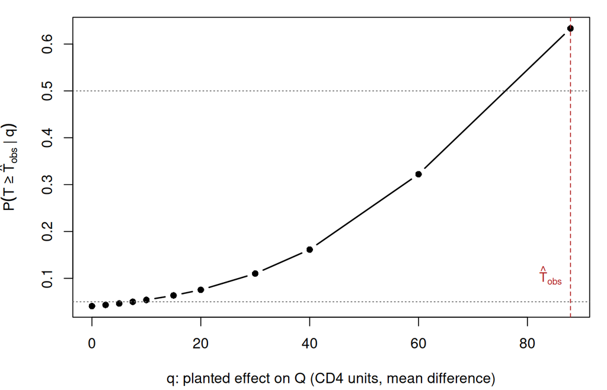

The calibration curve: P(T ≥ T̂_obs | q) against the planted effect q, with the observed statistic marked. Dotted guides at 0.05, 0.5, 0.95.

```r
op <- par(mar = c(4.2, 4.2, 1, 1))
plot(cb$q, cb$p_ge_Tobs, type = "b", pch = 16, lwd = 1.6,
     xlab = "q: planted effect on Q (CD4 units, mean difference)",
     ylab = expression(P(T >= hat(T)[obs] ~ "|" ~ q)))
abline(h = c(0.05, 0.5, 0.95), lty = 3, col = "grey40")
abline(v = S$meta$T_obs, lty = 2, col = "firebrick")
text(S$meta$T_obs, 0.1, expression(hat(T)[obs]), pos = 2, col = "firebrick",
     cex = 0.9)
```

```r
par(op)
```

This is *a consonance curve for the planted effect under the anchored two-point mixture model; not a posterior, not adjusted for anything outside the model*.

## 0.7 7. The `se_g` band

The family’s standard errors are the prevalence-scaled anchor se<sub>g</sub> = √(V<sub>eff</sub>[Q]/(n·P<sub>g</sub>)); the direct per-member value replaces V<sub>eff</sub>[Q] with the member’s own V<sub>eff</sub>[g]. The ratio se<sub>direct</sub>/se<sub>g</sub> at three rungs, overall and by purity band:

```r
sb <- S$seg_band
bands <- do.call(rbind, lapply(as.character(c(1L, 7L, 11L)), function(k) {
  b <- sb[[k]]
  data.frame(q = fmt(b$q, 2),
             range = paste0("[", fmt(b$range[1], 4), ", ",
                            fmt(b$range[2], 4), "]"),
             median = fmt(b$median, 4),
             hi  = fmt(b$by_band$median[b$by_band$band == "PQg >= 0.95"], 4),
             mid = fmt(b$by_band$median[b$by_band$band == "mid"], 4),
             lo  = fmt(b$by_band$median[b$by_band$band == "PQg < 0.25"], 4))
}))
gt(bands) |>
  cols_label(q = "q", range = "ratio range", median = "median",
             hi = md("median, PQg ≥ 0.95"), mid = "median, mid",
             lo = md("median, PQg < 0.25")) |>
  tab_source_note(md(paste0(
    "se~direct~/se~g~ over the ", fmt0(S$meta$M), " members; purity bands ",
    "PQg ≥ 0.95 / [0.25, 0.95) / < 0.25.")))
```

| q | ratio range | median | median, PQg ≥ 0.95 | median, mid | median, PQg < 0.25 |
| --- | --- | --- | --- | --- | --- |
| 0.01 | [0.9659, 1.0413] | 1.0059 | 1.0014 | 1.0025 | 1.0061 |
| 20.00 | [0.9659, 1.0492] | 1.0099 | 1.0015 | 1.0119 | 1.0099 |
| 87.92 | [0.9659, 1.0914] | 1.0290 | 1.0021 | 1.0619 | 1.0282 |

se<sub>direct</sub>/se<sub>g</sub> over the 4508 members; purity bands PQg ≥ 0.95 / [0.25, 0.95) / < 0.25.

At the top rung the largest deviation of the ratio from 1 is 9.14% — above the ~5% reporting band, so the prevalence-scaled approximation is accompanied by the sensitivity run below.

```r
sv <- S$sensitivity$table
gt(data.frame(
  run = sv$run,
  det10 = paste0(fmt(sv$det_at_analyst, 4), " ± ",
                 fmt(sv$det_at_analyst_se, 4)),
  p05 = paste0(fmt(sv$power_at_c1_05, 4), " ± ",
               fmt(sv$power_at_c1_05_se, 4)),
  p10 = paste0(fmt(sv$power_at_c1_10, 4), " ± ",
               fmt(sv$power_at_c1_10_se, 4)),
  pT = paste0(fmt(sv$p_ge_Tobs, 4), " ± ", fmt(sv$p_ge_Tobs_se, 4)),
  EnH = fmt(sv$EnH, 1), EbetaH = fmt(sv$EbetaH, 2),
  Eppv = fmt(sv$Eppv, 3))) |>
  cols_label(run = "", det10 = md(paste0("rate at c1 = ",
                                         fmt0(S$meta$analyst_c1))),
             p05 = md(paste0("power at ", fmt0(S$meta$c1_05))),
             p10 = md(paste0("power at ", fmt0(S$meta$c1_10))),
             pT = md("P(T ≥ T̂~obs~)"),
             EnH = md("E\\|Ĥ\\|"), EbetaH = md("E[β(Ĥ)]"),
             Eppv = "E[PPV]") |>
  tab_source_note(md(paste0(
    "Top rung (q = T̂~obs~) re-evaluated with the family's se~g~ replaced ",
    "by the member-direct se~direct~ — one draw set, same seed. Labeled as ",
    "the breadth ladder labeled it: **a sensitivity, not a constructor, ",
    "not adopted**.")))
```

|  | rate at c1 = 10 | power at 86 | power at 79 | P(T ≥ T̂<sub>obs</sub>) | E\|Ĥ\| | E[β(Ĥ)] | E[PPV] |
| --- | --- | --- | --- | --- | --- | --- | --- |
| primary (se_g) | 0.9660 ± 0.0004 | 0.6604 ± 0.0011 | 0.7534 ± 0.0010 | 0.6333 ± 0.0011 | 67.1 | 65.97 | 0.809 |
| sensitivity (se_direct) | 0.9652 ± 0.0004 | 0.6742 ± 0.0010 | 0.7669 ± 0.0009 | 0.6473 ± 0.0011 | 67.3 | 63.48 | 0.787 |

Top rung (q = T̂<sub>obs</sub>) re-evaluated with the family’s se<sub>g</sub> replaced by the member-direct se<sub>direct</sub> — one draw set, same seed. Labeled as the breadth ladder labeled it: **a sensitivity, not a constructor, not adopted**.

## 0.8 8. Limitations

- **The between-rule E|Ĥ| gap.** In the MD40/MD120 verification fixtures the wrapper’s expected declared-subgroup size differed from the measured search’s by about two subjects, an offset that did not scale with the planted harm. The same wrapper machinery produces the E|Ĥ| column here; a constant-order offset of that size should be assumed rather than precision at the single-subject level.
- **Q is not in the family.** With this analysis’s numbers: Ĥ’s `cd40` threshold (507) is off the population grid (nearest cut 506), the nearest member matches with purity 0.9969, and no member is identical. Every “power” number is therefore the power to declare *some* rule, scored against a Q the family can express only to ~0.31% of its membership — the honest representation of the search as the analyst configured it.
- **The mixture stylization.** Truths are a two-point effect mixture on the data’s own covariate rows with a GLM baseline surface; real heterogeneity is not two-valued. The calibration curve inherits this: it is a consonance statement inside the model, per the caveat above.
- **Fixed-family conditioning.** The evaluation conditions on the no-front-end family (`use_lasso = use_grf = FALSE`, the MR-anchor configuration). The compare-all document’s front-ends-on arms search a data-dependent family; their operating characteristics are a different (conditional-on-family) estimand and are not evaluated here. The cut locations themselves are quantile-derived and would move under resampling; the evaluation holds them at their population values.

# 1 Reproducibility payload

```
Wrote payload to: /home/larryleon/Documents/GitHub/forestsearch/quarto/applications/actg175/_payloads/analysis_actg175_continuous_oc_evaluation/analysis_actg175_continuous_oc_evaluation_payload.rds
```